# Week 2 Day 2 Homework

## Question 1

Load in the libraries you need, and look at the backpack data. Take note of variable names and dimensions.

```r
library(tidyverse)
library(CodeClanData)
view(backpack)
glimpse(backpack)
```

```
## Rows: 100
## Columns: 9
## $ backpack_weight <int> 9, 8, 10, 6, 8, 5, 8, 4, 5, 2, 8, 21, 11, 11, 12, 11, …
## $ body_weight     <int> 125, 195, 120, 155, 180, 240, 170, 185, 130, 120, 135,…
## $ ratio           <dbl> 0.0720000, 0.0410256, 0.0833333, 0.0387097, 0.0444444,…
## $ back_problems   <int> 1, 0, 1, 0, 0, 0, 0, 1, 0, 0, 0, 0, 0, 1, 1, 0, 1, 0, …
## $ major           <fct> Bio, Philosophy, GRC, CSC, EE, History, CM, ARCE, Bio,…
## $ year            <int> 3, 5, 4, 6, 2, 0, 3, 5, 4, 5, 3, 5, 4, 4, 3, 4, 4, 3, …
## $ sex             <fct> Female, Male, Female, Male, Female, Male, Male, Female…
## $ status          <fct> U, U, U, G, U, G, U, U, U, U, U, U, U, U, U, U, U, U, …
## $ units           <int> 13, 12, 14, 0, 14, 0, 15, 18, 14, 8, 15, 12, 16, 16, 1…
```

```r
skimr::skim(backpack)
```

Data summary

| Name | backpack |
| --- | --- |
| Number of rows | 100 |
| Number of columns | 9 |
| _______________________ |  |
| Column type frequency: |  |
| factor | 3 |
| numeric | 6 |
| ________________________ |  |
| Group variables | None |

**Variable type: factor**

| skim_variable | n_missing | complete_rate | ordered | n_unique | top_counts |
| --- | --- | --- | --- | --- | --- |
| major | 0 | 1 | FALSE | 41 | Bio: 9, Bus: 8, LS: 7, ME: 6 |
| sex | 0 | 1 | FALSE | 2 | Fem: 55, Mal: 45 |
| status | 0 | 1 | FALSE | 2 | U: 97, G: 3 |

**Variable type: numeric**

| skim_variable | n_missing | complete_rate | mean | sd | p0 | p25 | p50 | p75 | p100 | hist |
| --- | --- | --- | --- | --- | --- | --- | --- | --- | --- | --- |
| backpack_weight | 0 | 1 | 11.66 | 5.77 | 2.00 | 8.00 | 11.00 | 14.25 | 35.00 | ▅▇▂▁▁ |
| body_weight | 0 | 1 | 153.05 | 29.40 | 105.00 | 130.00 | 147.50 | 170.00 | 270.00 | ▆▇▂▁▁ |
| ratio | 0 | 1 | 0.08 | 0.04 | 0.02 | 0.05 | 0.07 | 0.10 | 0.18 | ▆▇▆▃▁ |
| back_problems | 0 | 1 | 0.32 | 0.47 | 0.00 | 0.00 | 0.00 | 1.00 | 1.00 | ▇▁▁▁▃ |
| year | 0 | 1 | 3.20 | 1.39 | 0.00 | 2.00 | 3.00 | 4.00 | 6.00 | ▃▆▇▆▆ |
| units | 0 | 1 | 14.27 | 2.81 | 0.00 | 13.00 | 15.00 | 16.00 | 19.00 | ▁▁▁▇▆ |

```r
summary(backpack)
```

```
##  backpack_weight  body_weight        ratio         back_problems      major
##  Min.   : 2.00   Min.   :105.0   Min.   :0.01600   Min.   :0.00   Bio    : 9
##  1st Qu.: 8.00   1st Qu.:130.0   1st Qu.:0.05121   1st Qu.:0.00   Bus    : 8
##  Median :11.00   Median :147.5   Median :0.07143   Median :0.00   LS     : 7
##  Mean   :11.66   Mean   :153.1   Mean   :0.07713   Mean   :0.32   ME     : 6
##  3rd Qu.:14.25   3rd Qu.:170.0   3rd Qu.:0.09630   3rd Qu.:1.00   CPE    : 5
##  Max.   :35.00   Max.   :270.0   Max.   :0.18103   Max.   :1.00   AGB    : 4
##                                                                   (Other):61
##       year         sex     status     units
##  Min.   :0.0   Female:55   G: 3   Min.   : 0.00
##  1st Qu.:2.0   Male  :45   U:97   1st Qu.:13.00
##  Median :3.0                      Median :15.00
##  Mean   :3.2                      Mean   :14.27
##  3rd Qu.:4.0                      3rd Qu.:16.00
##  Max.   :6.0                      Max.   :19.00
##
```

The data has 100 rows and 9 columns. There are 6 numeric and 3 factor columns. There are no missing values.

## Question 2

What is the distribution of backpack weights that students are carrying? Choose an appropriate graph to show the distribution.

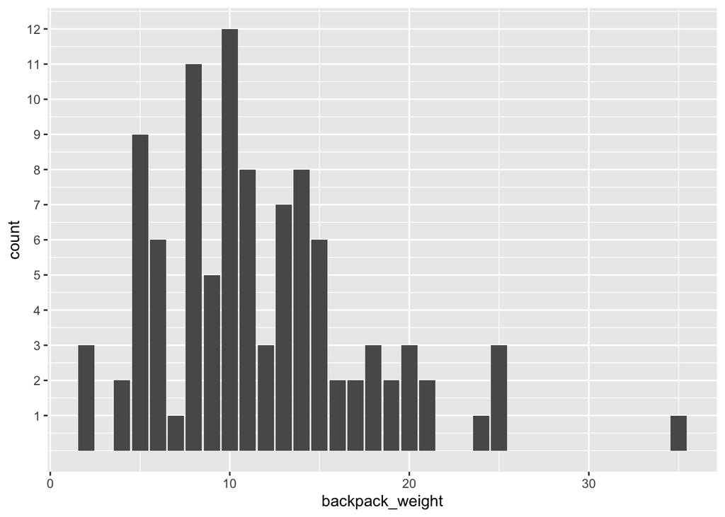

```r
ggplot(backpack) +
  aes(backpack_weight) +
  geom_bar() +
  scale_y_continuous(breaks = 1:13)
```

The backpack weights range from 2 to 35. There are 12 backpacks which weigh 10, this is the highest number of any single weight. The mean weight is 11.66 and the median is 11.

## Question 3

Are there differences in backpack weight between sex?

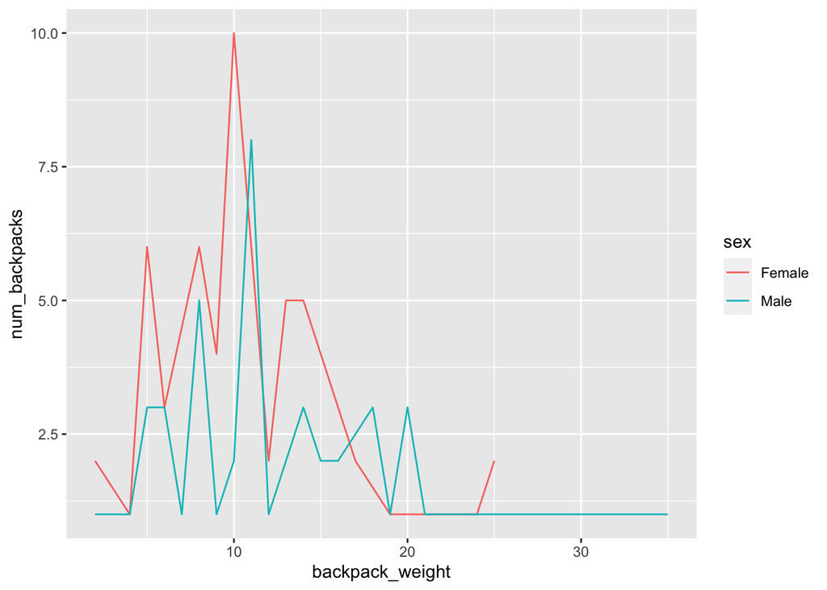

```r
backpack %>%
  group_by(backpack_weight, sex) %>%
  summarise(num_backpacks = n())%>%
ggplot() +
  aes(backpack_weight, num_backpacks, colour = sex) +
  geom_line()
```

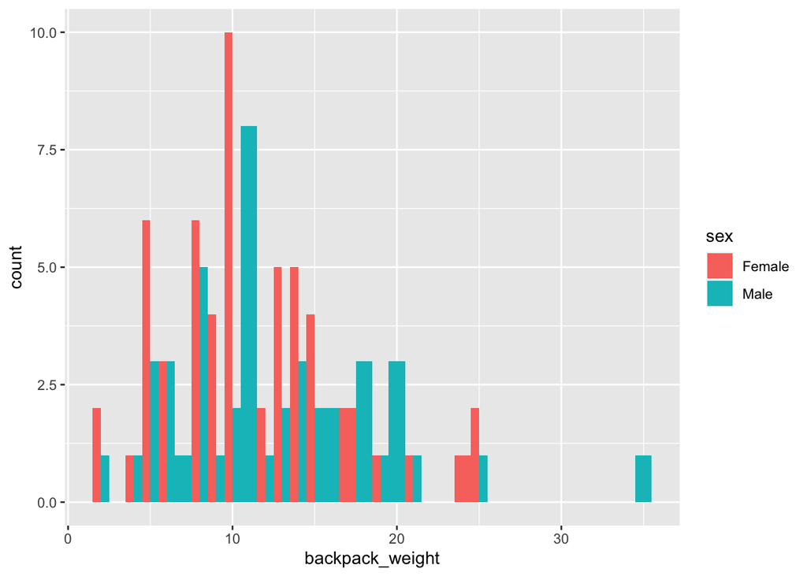

```r
ggplot(backpack) +
  aes(backpack_weight, fill = sex) +
  geom_bar(position = "dodge", width = 1)
```

```r
# need to half the sizes of the bars
```

The weight differences of backpacks between males and females is not obvious. You could maybe say that the weight of backpacks carried by males is spread over a wider range, while female backpack weight is more concentrated around 10.

## Queston 4

What is the relationship between body weight and backpack weight?

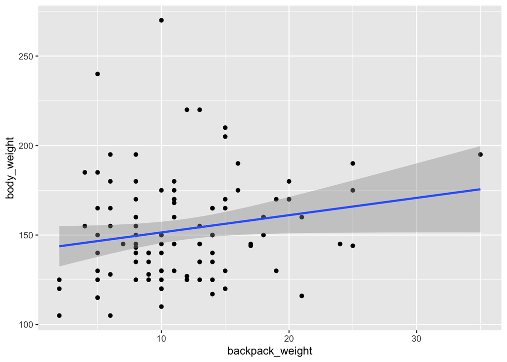

```r
ggplot(backpack) +
  aes(backpack_weight, body_weight) +
  geom_point() +
  geom_smooth(method = "lm")
```

This data does not show a relationship between body weight and backpack weight.

## Question 5

Is this relationship different between men and women? Choose an appropriate plot and interpret your findings.

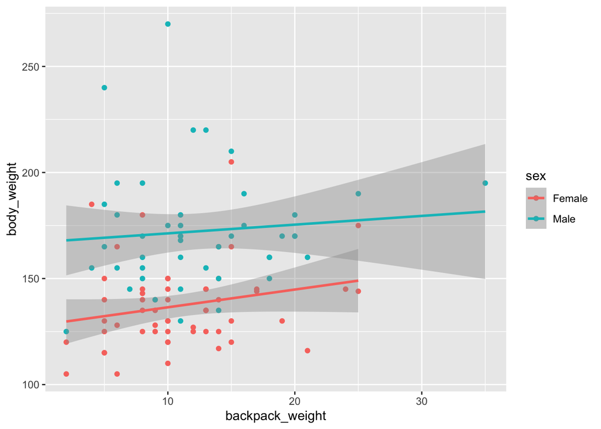

```r
ggplot(backpack) +
  aes(backpack_weight, body_weight, colour = sex) +
  geom_point() +
  geom_smooth(method = "lm")
```

For males there is still no relationship between body weight and backpack weight. For females there is perhaps a slight relationship but it looks like it is still within the error range.

## Question 6

What proportion of students report back pain?

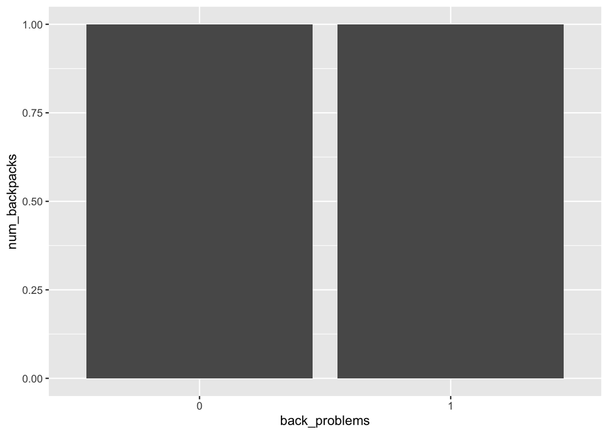

```r
backpack %>%
  mutate(back_problems = factor(back_problems)) %>%
  group_by(back_problems) %>%
  summarise(num_backpacks = n()) %>%
ggplot() +
  aes(x = back_problems, y = num_backpacks) +
  geom_col(position = "fill")
```

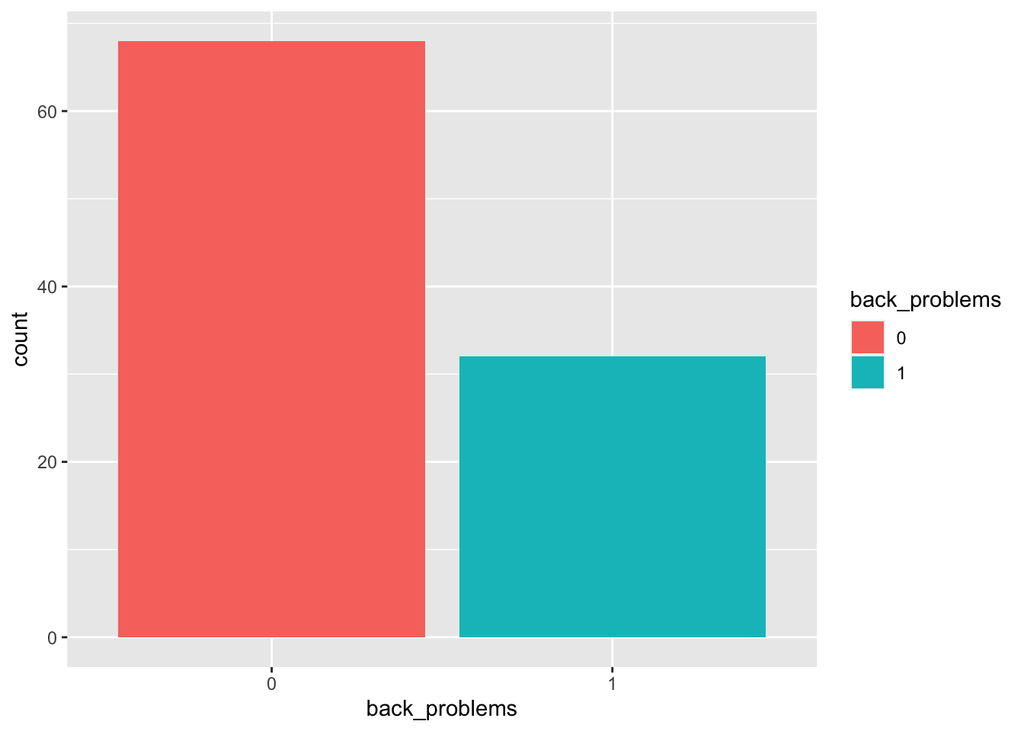

```r
backpack %>%
  mutate(back_problems = factor(back_problems)) %>%
ggplot() +
  aes(back_problems) +
  geom_bar(aes(fill = back_problems))
```

## Question 7

Is this proportion different between men and women?

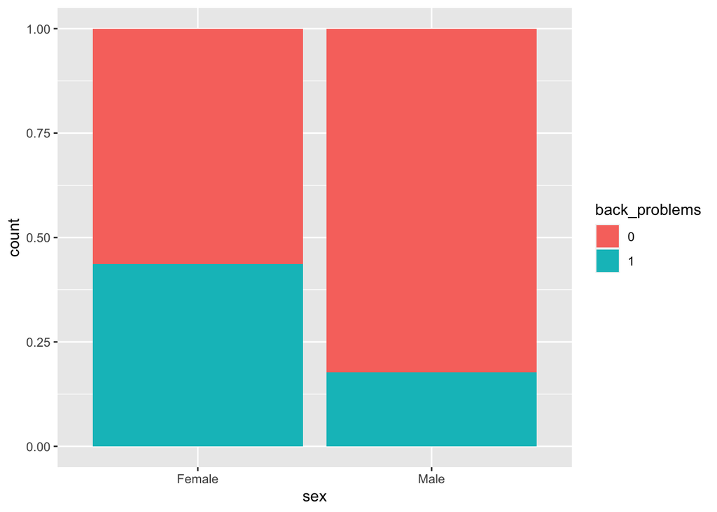

```r
backpack %>%
  mutate(back_problems = factor(back_problems)) %>%
ggplot() +
  aes(sex) +
  geom_bar(aes(fill = back_problems), position = "fill")
```

Yes, proportionally more woman than men have back problems.

## Question 8

Now you’ve investigated your data separately, create plots to describe the relationship between backpack weight, body weight, gender and reported backpain.

Try both backpack_weight and body_weight as well as the ratio.

Hint: faceting would be useful here.

# Extension

## Question 1

Does reported backpain differ across the year groups? Ignore year 0 in your data.

## Question 2

Is there a difference between how heavy the bags those in different years carry?